# In-Class Computing Task 16

Math 253: Statistical Computing & Machine Learning

Building your own spline fitter

In this programming activity, you’re going to build your own cubic spline fitter.

# The knots

Recall that in specifying a cubic spline, the *only* parameter to be selected is the number of knots, $k$. It’s usual to place the knots at evenly spaced points inside the range of the input variable $x$. A sensible definition of “evenly spaced” is that each of the intervals between knots contain roughly the same number of $x$ values. In other words, the knots will be placed at evenly spaced quantiles of $x$. For instance, if $k=2$, the knots are placed at the $\frac{1}{3}$ and $\frac{2}{3}$ quantiles.

Write a function `my_knots(x, k)` which takes the $x$ data and the number of knots as arguments. The evenly spaced quantiles will be $\frac{1}{k+1}, \frac{2}{k+1}, \ldots, \frac{k}{k+1}$. Use the `quantile()` function to calculate the values at which these quantiles occur.

# The basis set

For fitting the spline, you are going to construct a model matrix based on $x$. The model matrix will consist of a set of vectors, $v_1, v_2, \ldots$ each of the same length as $x$. Vector $v_i$ is computed by applying some function $f_i()$ to $x$. Here are the functions $f_i()$ for a cubic spline:

- The constant function $f_1(x) = 1$.
- The linear function, $f_2(x) = x$.
- The quadratic function $f_3(x) = x^2$.
- The cubic function $f_4(x) = x^3$
- Another $k$ functions, each of which is $(x - \xi_j)^3_+$, where $\xi_j$ is the $j$th knot.

Recall that $(x - \xi)^3_+$ means that the function has value 0 when $x < \xi$ and value $(x - \xi)^3$ otherwise.

Constructing the first four vectors in the model matrix is easy. Call the model matrix `MM`.

```r
MM <- cbind(1, x, x^2, x^3)
```

To add in the $k$ vectors containing $(x - \xi_j)^3_+$, use a loop over each of the knots, adding the new vector to the model matrix like this:

```r
MM <- cbind(MM, new_vector)
```

Package up the computations to create the model matrix into a function `spline_model_matrix(x, knot_locations)`.

# Finding the best linear combination

Once you have your `knots()` and `spline_model_matrix()` functions, finding the best least squares fit is straightforward, using `lm()` like this:

```r
spline_coefs <- coef(lm(y ~ MM))
```

Create a function `fit_spline()` that does the calculations. The `fit_spline()` function will have a formula interface. It will return a list of items relevant to calculating the value of the spline at any point $x$. Here’s the function:

```r
fit_spline <- function(formula, k=2, data=parent.frame()) {
  y <- eval(formula[[2]], envir=data)
  x <- eval(formula[[3]], envir=data)
  knot_locations <- my_knots(x, k)
  MM <- spline_model_matrix(x, knot_locations)
  mod <- lm(y ~ MM - 1)
  res <- list(coef = coef(mod), knots = knot_locations, cov = vcov(mod))
  class(res) <- "my_spline"

  return(res)
}
```

I’ve written this function for you because it contains the statements to make use of a formula as well as something new, use of the `class()` function. More about that later. The component `cov` gives the covariance matrix of the model coefficients. Those will be used later to find standard errors on the spline values, confidence intervals, and prediction intervals.

# The predict function

Write a corresponding predict function called `predict.my_spline()`.

This name allows you to refer to the function simply with `predict()`. R, seeing that the first argument is an object of class `my_spline`, will automatically call `predict.my_spline()`.

```r
predict.my_spline <-
  function(mod, newx, level = 0.95,
           intervals=c("none", "confidence", "prediction")) {
  intervals <- match.arg(intervals)
  MM <- spline_model_matrix(newx, mod$knots)
  vals <- MM %*% mod$coef
  se <- sqrt(rowSums(MM %*% mod$cov * MM))
  if (intervals == "none") return(vals)
  else return(NULL) # for future use
}
```

Again, I’ve given you a template. You’ll add on to it later.

Used together, `fit_spline()` and `predict()` (that is, `predict.my_spline()`) enable you construct a spline-function model $\hat{f(x)}$

Try out your function on the `Wage` data from the ISLR package, finding a smooth model of wage versus age.

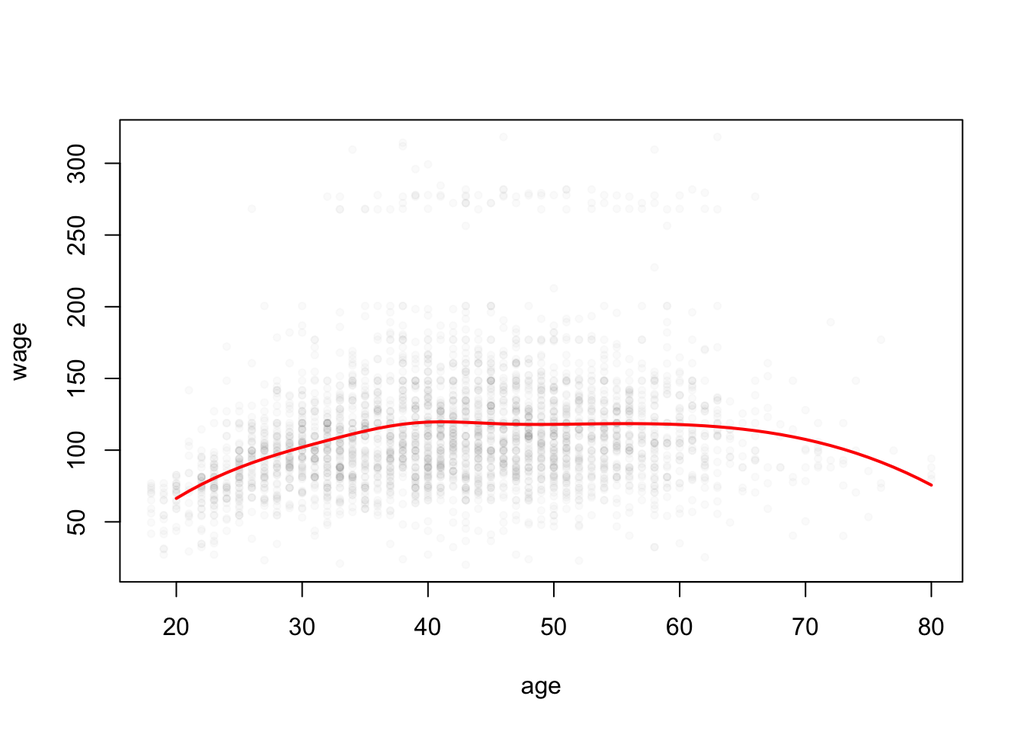

Figure 1. A cubic spline with 4 knots modeling wage versus age.

# Confidence intervals

Modify `predict.my_spline()` so that if the argument `intervals` is set to `"confidence"`, you will return a data frame with three columns: `vals`, `upper` and `lower`. Following the usual procedure for constructing 95% confidence intervals, `upper` will be `vals` plus 2 times the standard error `se`, and similarly with `lower`.

Strictly speaking, the multiplier for a confidence level of `level` is `qt((1-level)/2, df=dfr)`, where `dfr` is the degrees of freedom of the residual.

Revise your plot (as in Figure 1) to show the upper and lower confidence intervals.

# Prediction intervals

Modify `predict.my_spline()` again so that if the argument `intervals` is set to `"prediction"`, you will return the three-column data frame, but giving the 95% prediction intervals. These will be based on `se` and the standard error of the residuals `rse` from the fit. The prediction standard error is `sqrt(se^2 + rse^2)`. You’ll have to go back to `fit_spline()` and arrange for it to include the `rse`. This is the sum of square residuals divided by the degrees of freedom in the residual.

The residual degrees of freedom is the number of points $n$ in the data used for fitting minus the number of columns in the model matrix.

# How many knots?

1. Examine the spline fit to wage vs age as you change the number of knots to get a sense for how the spline’s smoothness and prediction intervals vary.
2. Divide `Wage` into training and testing sets. Find the number of knots that minimizes the mean square error on the testing set.